# ggplot2: 10 Position Scales and Axes

This notebook is based on exercises completed from [ggplot2: Elegant Graphics for Data Analysis](https://ggplot2-book.org/index.html).

```r
library(tidyverse)
```

## 10.1.4 Exercises

1. The following code creates two plots of the mpg dataset. Modify the code so that the legend and axes match, without using faceting!

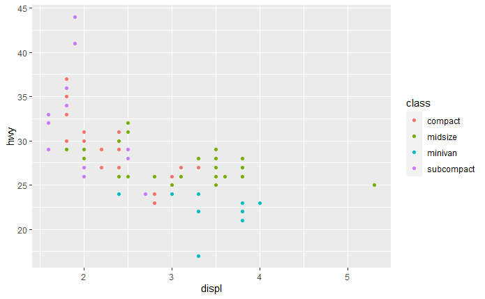

```r
# given
fwd <- subset(mpg, drv == "f")
rwd <- subset(mpg, drv == "r")


ggplot(fwd, aes(displ, hwy, colour = class)) + geom_point()
```

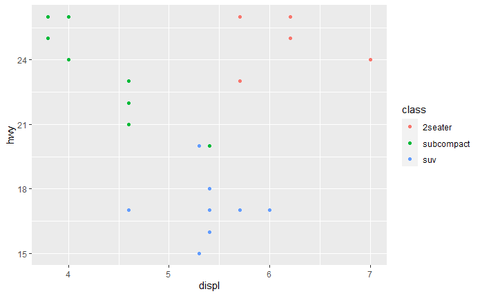

```r
ggplot(rwd, aes(displ, hwy, colour = class)) + geom_point()
```

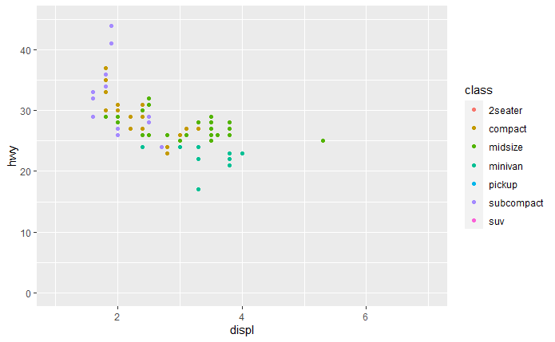

```r
# make match
fwd <- mpg %>%
  mutate(displ = if_else(drv == "f", displ, NA_real_))

rwd <- mpg %>%
  mutate(displ = if_else(drv == "r", displ, NA_real_))

ggplot(fwd, aes(displ, hwy, colour = class)) +
  geom_point() +
  scale_x_continuous(limits = c(1,7)) +
  scale_y_continuous(limits = c(0,45))
```

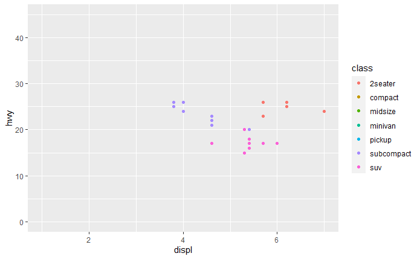

```r
ggplot(rwd, aes(displ, hwy, colour = class)) +
  geom_point() +
  scale_x_continuous(limits = c(1,7)) +
  scale_y_continuous(limits = c(0,45))
```

```r
NA
NA
```

2. What happens if you add two xlim() calls to the same plot? Why?

The last version is used. Warning given: “Scale for ‘x’ is already present. Adding another scale for ‘x’, which will replace the existing scale.”

[figure not shown]

```r
ggplot(fwd, aes(displ, hwy, colour = class)) +
  geom_point() +
  xlim(3,5) +
  xlim(4,7)
```

3. What does scale_x_continuous(limits = c(NA, NA)) do?

Nothing changes since these are the default scales for all plots. All points are included in the graph. Use NA when you only want to set the limit on the other side.

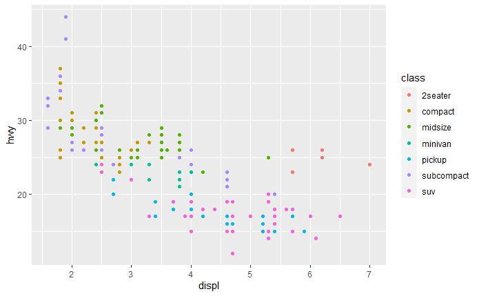

```r
ggplot(mpg, aes(displ, hwy, colour = class)) +
  geom_point() +
  scale_x_continuous(limits = c(NA, NA))
```

4. What does expand_limits() do and how does it work? Read the source code.

Sometimes you may want to ensure limits include a single value, for all panels or all plots. This function is a thin wrapper around geom_blank() that makes it easy to add such values.

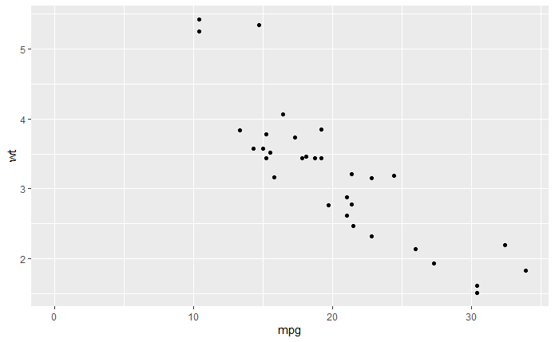

```r
p <- ggplot(mtcars, aes(mpg, wt)) + geom_point()
p + expand_limits(x = 0)
```

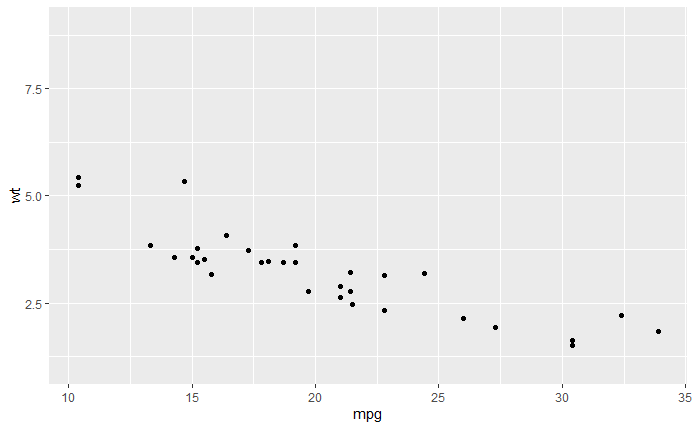

```r
p + expand_limits(y = c(1, 9))
```

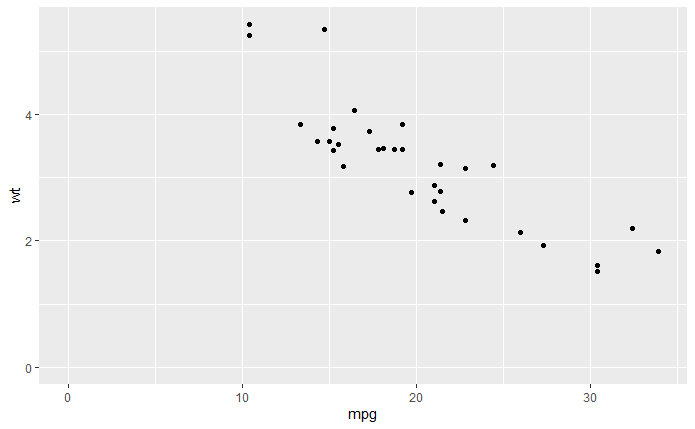

```r
p + expand_limits(x = 0, y = 0)
```

## 10.1.8 Exercises

1. Recreate the following graphic: Adjust the y axis label so that the parentheses are the right size.

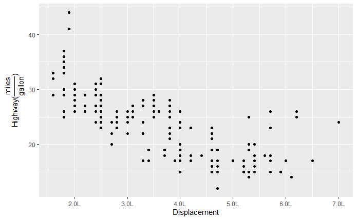

2. List the three different types of object you can supply to the breaks argument. How do breaks and labels differ?

The objects that you can supply to the breaks argument is a vector for manual, a custom function, or a function from the scales package. Labels must be a character vector to display text, whereas the breaks is the same type as the axes and it is where the tick marks go.

3. What label function allows you to create mathematical expressions? What label function converts 1 to 1st, 2 to 2nd, and so on?

Within scale_xy_continuous use label_math or label_parse within labels =

Or you can use expression() from ?plotmath to make math expression in the labels vector.

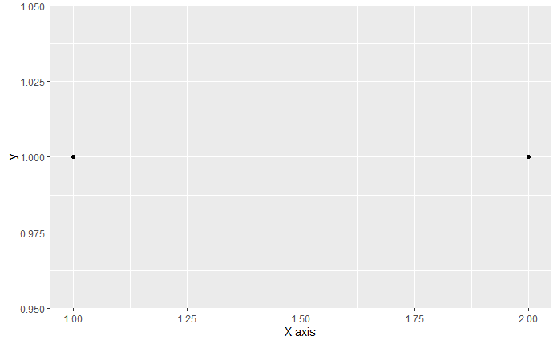

```r
# http://rstudio-pubs-static.s3.amazonaws.com/224435_1a0eb58a057a4c69b1fe1eb21553ecef.html
df <- data.frame(x = 1:2, y = 1, z = "a")
p <- ggplot(df, aes(x, y)) + geom_point()
p + scale_x_continuous("X axis")
```

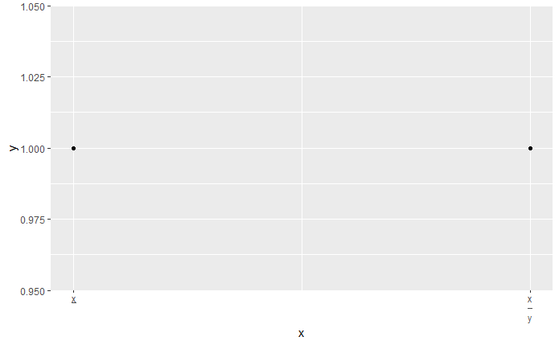

```r
p + scale_x_continuous(breaks = scales::breaks_extended(n = 2),
                       labels = c(expression(underline(x)),
                                  expression(frac(x, y))))
```

```r
# modified for labels
```

scales::label_ordinal() gives the rank as labels.